# Section 12: Two-Sample Proportion Inference

```r
library(tidyverse)
```

# CI for p_1 - p_2

Return to the chimpanzee data from last section.

```r
chimpanzee <- read_csv("../../data/chimpanzee.csv")
head(chimpanzee)
```

```
## # A tibble: 6 × 6
##   actor partner prosocial selfish prosocial_color selfish_color
##   <chr> <chr>       <dbl>   <dbl> <chr>           <chr>
## 1 A     I              22       8 green           purple
## 2 A     G              16      14 yellow          black
## 3 A     H              22       8 blue            red
## 4 A     none           16      14 pink            gray
## 5 B     H              18      12 black           yellow
## 6 B     C              23       7 purple          green
```

What is the difference in the proportion of prosocial choices by chimpanzee C with versus without a partner?

```r
sum1 <- chimpanzee %>%
  mutate(session_type = case_when(
    partner == "none" ~ "no partner",
    TRUE ~ "partner"
  )) %>%
  group_by(actor, session_type) %>%

  summarize(prosocial = sum(prosocial),
            selfish = sum(selfish),
            n = prosocial + selfish,
            p_hat = prosocial/n)
sum1 %>%
  filter(actor == "C") %>%
  arrange(desc(session_type))
```

```
## # A tibble: 2 × 6
## # Groups:   actor [1]
##   actor session_type prosocial selfish     n p_hat
##   <chr> <chr>            <dbl>   <dbl> <dbl> <dbl>
## 1 C     partner             57      33    90 0.633
## 2 C     no partner          17      13    30 0.567
```

```r
# Simulation to show normal distribution

## simulation parameters
B <- 10000
n1 <- 90
p1 <- 0.6

n2 <- 30
p2 <- 0.5

## do the simulation
sim <- tibble(
  phat_1 = rbinom(B, n1, p1) / n1,
  phat_2 = rbinom(B, n2, p2) / n2,
  diff = phat_1 - phat_2)
```

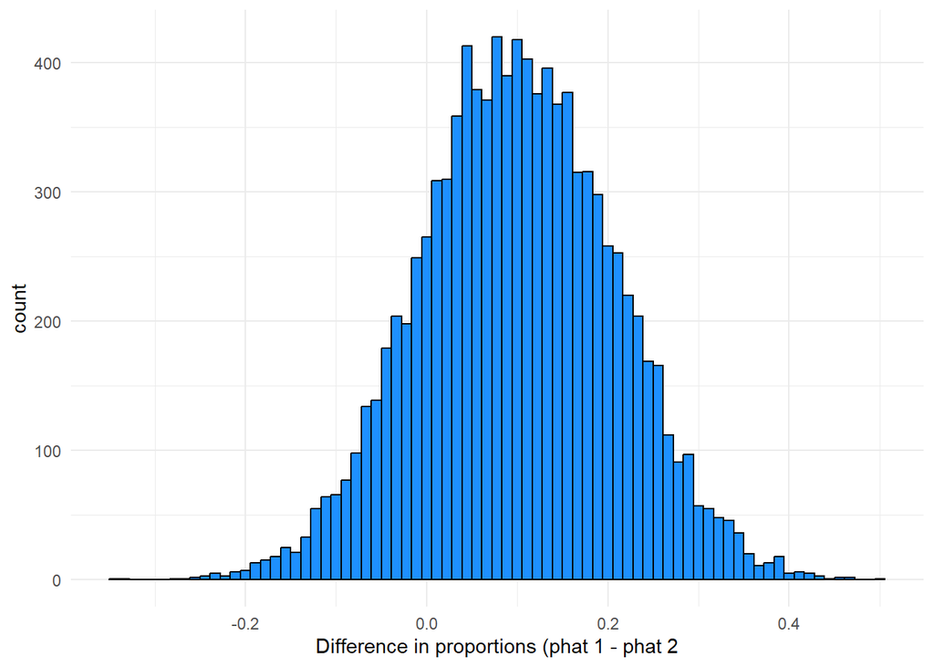

```r
## Graphical summary
ggplot(sim, aes(x = diff)) +
  geom_histogram(binwidth = 1/90,
                 color = "black", fill = "dodgerblue") +
  xlab("Difference in proportions (phat 1 - phat 2") +
  theme_minimal()
```

```r
## Numeric summary
sim_summary <- sim %>%
  summarize(mean = mean(diff),  ## this should be very close to 0.1
            sd = sd(diff)) ## this should be very close to 0.105
sim_summary
```

```
## # A tibble: 1 × 2
##     mean    sd
##    <dbl> <dbl>
## 1 0.0996 0.107
```

Let’s build a CI for a difference in proportions. $n2$ might not quite be large enough, but the normal approximation will still be mostly accurate.

```r
x1 <- 57
n1 <- 90
x2 <- 17
n2 <- 30

phat1 <- x1 / n1
phat2 <- x2 / n2

pt_est <- phat1 - phat2

se <- sqrt(phat1*(1-phat1)/n1 + phat2*(1-phat2)/n2)

cv <- qnorm(0.975)

c(pt_est - cv*se, pt_est + cv*se)
```

```
## [1] -0.1366925  0.2700259
```

### Try it out

Build a 95% CI for the difference in prosocial behavior for chimpanzee B with and without a partner.

## Hypothesis testing for p_1 - p_2

Let’s look at chimpanzee C again:

```r
sum1 %>%
  filter(actor == "C") %>%
  arrange(desc(session_type))
```

```
## # A tibble: 2 × 6
## # Groups:   actor [1]
##   actor session_type prosocial selfish     n p_hat
##   <chr> <chr>            <dbl>   <dbl> <dbl> <dbl>
## 1 C     partner             57      33    90 0.633
## 2 C     no partner          17      13    30 0.567
```

Now, conduct a hypothesis test for the difference in proportions at the 5% level. The standard error is calculated with an estimated common proportion, p-hat.

```r
x1 <- 57
n1 <- 90
x2 <- 17
n2 <- 30

p_hat <- (x1 + x2)/(n1 + n2)

numerator <- (x1/n1) - (x2/n2)  # Observed difference in proportions

denominator <- sqrt(p_hat*(1-p_hat)*(1/n1 + 1/n2))  # SE using common proportion

test_stat <- numerator/denominator
test_stat
```

```
## [1] 0.6504089
```

If H0 is true and p_1 = p_2, then our test statistic came from N(0, 1). We use the standard normal as our null distribution. We want to find the area above our test statistic to find evidence that p_1 - p_2 is positive.

```r
pnorm(test_stat, lower.tail = F)
```

```
## [1] 0.2577141
```

We can also use a rejection region approach. For a one-sided test, the rejection region is in the upper tail.

```r
qnorm(0.95)
```

```
## [1] 1.644854
```

Our test statistic does not fall in the rejection region.

### Try it out

Perform a 5% level test of *two-sided* hypotheses for p_1 - p_2 != 0, for chimpanzee B.